# **Wholesale customer data analysis**

- Name: Ha Ngo
- Email: (nvh1211@gmail.com)
- Date: 09/5/2024

## Task 1: Problem Formulation, Data Acquisition and Preparation

```python
import pandas as pd
import numpy as np
%matplotlib inline
import matplotlib.pyplot as plt
```

I have chosen the data set 'Wholesale customers data.csv'. This data set describes customers of a wholesale distributor and shows how much they spend each year on different types of products, measured in monetary units.

```python
# Load the CSV data into a pandas DataFrame
df = pd.read_csv('Wholesale customers data.csv')
# Check for missing values
missing_values = df.isnull().sum()

print(missing_values)
```

```
Channel             0
Region              0
Fresh               0
Milk                0
Grocery             0
Frozen              0
Detergents_Paper    0
Delicassen          0
dtype: int64
```

```python
# Loading the first 5 rows of the dataframe.
df.head()
```

|  | Channel | Region | Fresh | Milk | Grocery | Frozen | Detergents_Paper | Delicassen |
| --- | --- | --- | --- | --- | --- | --- | --- | --- |
| 0 | 2 | 3 | 12669 | 9656 | 7561 | 214 | 2674 | 1338 |
| 1 | 2 | 3 | 7057 | 9810 | 9568 | 1762 | 3293 | 1776 |
| 2 | 2 | 3 | 6353 | 8808 | 7684 | 2405 | 3516 | 7844 |
| 3 | 1 | 3 | 13265 | 1196 | 4221 | 6404 | 507 | 1788 |
| 4 | 2 | 3 | 22615 | 5410 | 7198 | 3915 | 1777 | 5185 |

```python
# Get an overview of the data set:
df.shape
```

```
(440, 8)
```

```python
df.info()
```

```
<class 'pandas.core.frame.DataFrame'>
RangeIndex: 440 entries, 0 to 439
Data columns (total 8 columns):
 #   Column            Non-Null Count  Dtype
---  ------            --------------  -----
 0   Channel           440 non-null    int64
 1   Region            440 non-null    int64
 2   Fresh             440 non-null    int64
 3   Milk              440 non-null    int64
 4   Grocery           440 non-null    int64
 5   Frozen            440 non-null    int64
 6   Detergents_Paper  440 non-null    int64
 7   Delicassen        440 non-null    int64
dtypes: int64(8)
memory usage: 27.6 KB
```

```python
df.describe()
```

|  | Channel | Region | Fresh | Milk | Grocery | Frozen | Detergents_Paper | Delicassen |
| --- | --- | --- | --- | --- | --- | --- | --- | --- |
| count | 440.000000 | 440.000000 | 440.000000 | 440.000000 | 440.000000 | 440.000000 | 440.000000 | 440.000000 |
| mean | 1.322727 | 2.543182 | 12000.297727 | 5796.265909 | 7951.277273 | 3071.931818 | 2881.493182 | 1524.870455 |
| std | 0.468052 | 0.774272 | 12647.328865 | 7380.377175 | 9503.162829 | 4854.673333 | 4767.854448 | 2820.105937 |
| min | 1.000000 | 1.000000 | 3.000000 | 55.000000 | 3.000000 | 25.000000 | 3.000000 | 3.000000 |
| 25% | 1.000000 | 2.000000 | 3127.750000 | 1533.000000 | 2153.000000 | 742.250000 | 256.750000 | 408.250000 |
| 50% | 1.000000 | 3.000000 | 8504.000000 | 3627.000000 | 4755.500000 | 1526.000000 | 816.500000 | 965.500000 |
| 75% | 2.000000 | 3.000000 | 16933.750000 | 7190.250000 | 10655.750000 | 3554.250000 | 3922.000000 | 1820.250000 |
| max | 2.000000 | 3.000000 | 112151.000000 | 73498.000000 | 92780.000000 | 60869.000000 | 40827.000000 | 47943.000000 |

## Task 2: Data Exploration:

### 2.1 Exploring each column

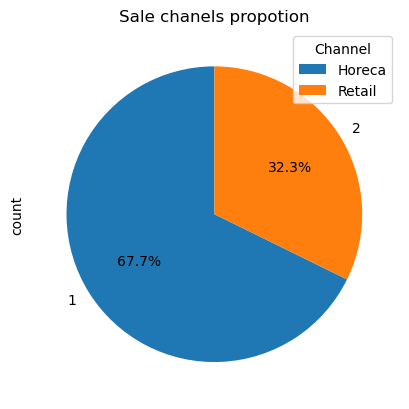

```python
# Exploring the Sale chanels
chanel = df['Channel'].value_counts()
plot = chanel.plot(kind='pie', y='total', autopct='%1.1f%%', startangle = 90,
               title='Sale chanels propotion')
plot.legend(title="Channel", loc="upper right", labels=['Horeca', 'Retail'])
```

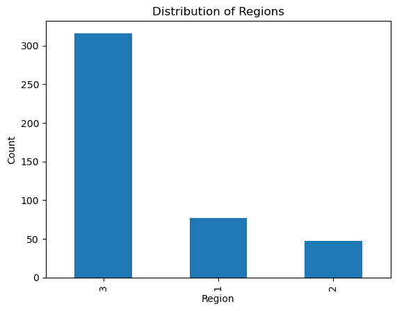

```python
# Exploring the location where goods are sold
region = df['Region'].value_counts()
region.plot(kind='bar')
plt.xlabel('Region')
plt.ylabel('Count')
plt.title('Distribution of Regions')
plt.show()
```

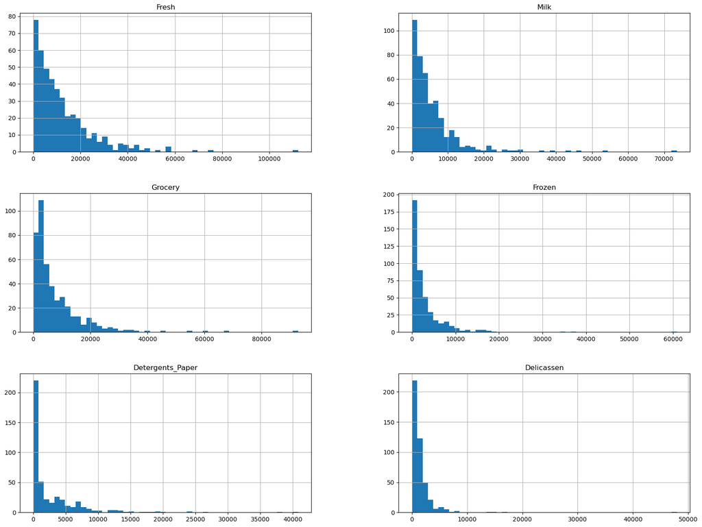

```python
# Explore the attribute of the other products
# Drop the 'Region' and 'Channel' columns
df_drop = df.drop(['Region', 'Channel'], axis=1)
df_drop.hist(bins=50, figsize=(20,15))
plt.show()
```

## 2.2 Exploring the relationships between all pairs of columns

```python
# Use the corr() method to explore the pairwise correlation of all columns
df_corr = df.corr()
print ("Correlation matrix between features:")
df_corr
```

```
Correlation matrix between features:
```

|  | Channel | Region | Fresh | Milk | Grocery | Frozen | Detergents_Paper | Delicassen |
| --- | --- | --- | --- | --- | --- | --- | --- | --- |
| Channel | 1.000000 | 0.062028 | -0.169172 | 0.460720 | 0.608792 | -0.202046 | 0.636026 | 0.056011 |
| Region | 0.062028 | 1.000000 | 0.055287 | 0.032288 | 0.007696 | -0.021044 | -0.001483 | 0.045212 |
| Fresh | -0.169172 | 0.055287 | 1.000000 | 0.100510 | -0.011854 | 0.345881 | -0.101953 | 0.244690 |
| Milk | 0.460720 | 0.032288 | 0.100510 | 1.000000 | 0.728335 | 0.123994 | 0.661816 | 0.406368 |
| Grocery | 0.608792 | 0.007696 | -0.011854 | 0.728335 | 1.000000 | -0.040193 | 0.924641 | 0.205497 |
| Frozen | -0.202046 | -0.021044 | 0.345881 | 0.123994 | -0.040193 | 1.000000 | -0.131525 | 0.390947 |
| Detergents_Paper | 0.636026 | -0.001483 | -0.101953 | 0.661816 | 0.924641 | -0.131525 | 1.000000 | 0.069291 |
| Delicassen | 0.056011 | 0.045212 | 0.244690 | 0.406368 | 0.205497 | 0.390947 | 0.069291 | 1.000000 |

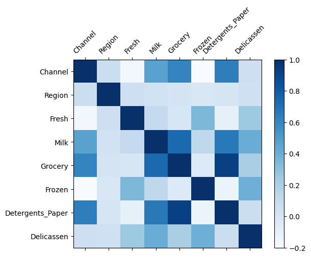

```python
# visualize correlation matrix
# Create a figure and a set of subplots
fig, ax = plt.subplots()

# Create a heatmap
cax = ax.matshow(df_corr, cmap='Blues')

# Create a colorbar
fig.colorbar(cax)

# Set the labels
labels = [''] + list(df.columns)
ax.set_xticklabels(labels, rotation=45)
ax.set_yticklabels(labels)

plt.show()
```

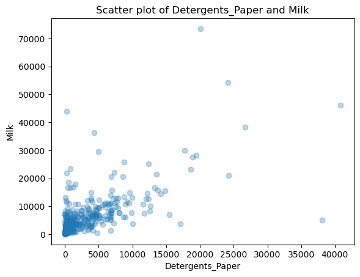

```python
# 1. Explore the relationship between Detergents_paper and Milk
plt.scatter(x=df['Detergents_Paper'], y=df['Milk'], alpha = 0.3)
plt.title('Scatter plot of Detergents_Paper and Milk')
plt.xlabel('Detergents_Paper')
plt.ylabel('Milk')
```

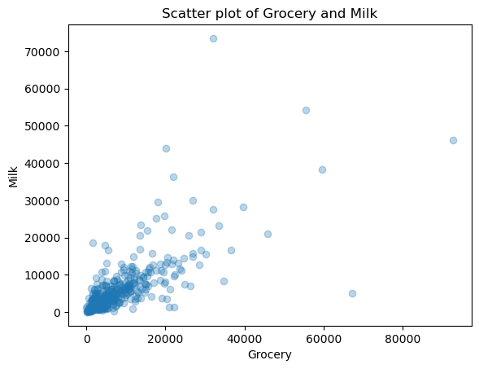

```python
# 2. Explore the relationship between Grocery and Milk
plt.scatter(x=df['Grocery'], y=df['Milk'], alpha = 0.3)
plt.title('Scatter plot of Grocery and Milk')
plt.xlabel('Grocery')
plt.ylabel('Milk')
```

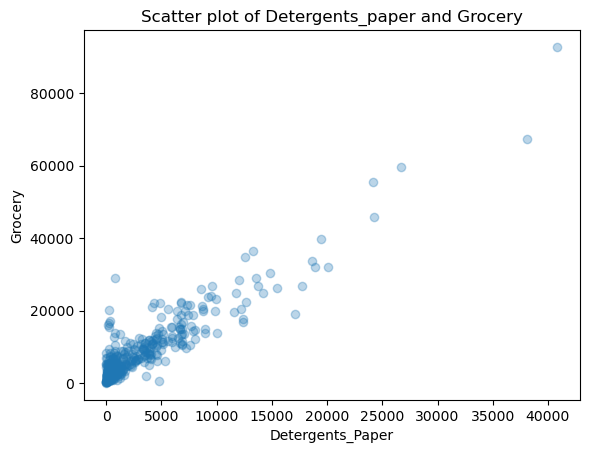

```python
# 3. Chanel and Detergents_paper
plt.scatter(x=df['Detergents_Paper'], y=df['Grocery'], alpha = 0.3)
plt.title('Scatter plot of Detergents_paper and Grocery')
plt.xlabel('Detergents_Paper')
plt.ylabel('Grocery')
```

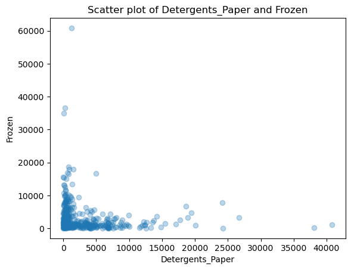

```python
# 4. Detergents_paper and Frozen
plt.scatter(x=df['Detergents_Paper'], y=df['Frozen'], alpha = 0.3)
plt.title('Scatter plot of Detergents_Paper and Frozen')
plt.xlabel('Detergents_Paper')
plt.ylabel('Frozen')
```

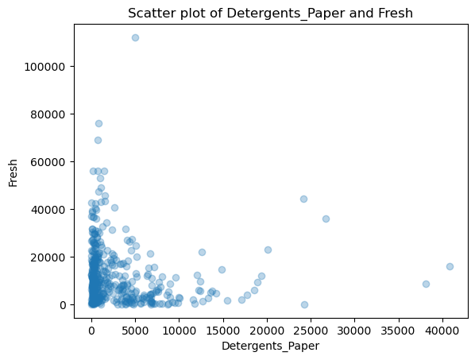

```python
# 4.Fresh and Detergents_paper
plt.scatter(x=df['Detergents_Paper'], y=df['Fresh'], alpha = 0.3)
plt.title('Scatter plot of Detergents_Paper and Fresh')
plt.xlabel('Detergents_Paper')
plt.ylabel('Fresh')
```

## 2.3 Question: "Do spending patterns differ between Horeca and Retail customers across product categories?"

```python
# Separate the Horeca customer channel for data exploration
df_horeca = df.loc[df['Channel'] == 1].reset_index(drop=True)

# Calculate a new column 'Total_Spend' across all product categories
df_horeca['Total_Spend'] = df_horeca[['Fresh', 'Milk', 'Grocery', 'Frozen', 'Detergents_Paper', 'Delicassen']].sum(axis=1)

df_horeca
```

|  | Channel | Region | Fresh | Milk | Grocery | Frozen | Detergents_Paper | Delicassen | Total_Spend |
| --- | --- | --- | --- | --- | --- | --- | --- | --- | --- |
| 0 | 1 | 3 | 13265 | 1196 | 4221 | 6404 | 507 | 1788 | 27381 |
| 1 | 1 | 3 | 5963 | 3648 | 6192 | 425 | 1716 | 750 | 18694 |
| 2 | 1 | 3 | 10253 | 1114 | 3821 | 397 | 964 | 412 | 16961 |
| 3 | 1 | 3 | 5876 | 6157 | 2933 | 839 | 370 | 4478 | 20653 |
| 4 | 1 | 3 | 7780 | 2495 | 9464 | 669 | 2518 | 501 | 23427 |
| ... | ... | ... | ... | ... | ... | ... | ... | ... | ... |
| 293 | 1 | 3 | 16731 | 3922 | 7994 | 688 | 2371 | 838 | 32544 |
| 294 | 1 | 3 | 29703 | 12051 | 16027 | 13135 | 182 | 2204 | 73302 |
| 295 | 1 | 3 | 39228 | 1431 | 764 | 4510 | 93 | 2346 | 48372 |
| 296 | 1 | 3 | 10290 | 1981 | 2232 | 1038 | 168 | 2125 | 17834 |
| 297 | 1 | 3 | 2787 | 1698 | 2510 | 65 | 477 | 52 | 7589 |

298 rows × 9 columns

```python
# Separate the Retail customer channel for data exploration
df_retail = df.loc[df['Channel'] == 2].reset_index(drop=True)

# Calculate a new column 'Total_Spend' across all product categories
df_retail['Total_Spend'] = df_retail[['Fresh', 'Milk', 'Grocery', 'Frozen', 'Detergents_Paper', 'Delicassen']].sum(axis=1)

df_retail
```

|  | Channel | Region | Fresh | Milk | Grocery | Frozen | Detergents_Paper | Delicassen | Total_Spend |
| --- | --- | --- | --- | --- | --- | --- | --- | --- | --- |
| 0 | 2 | 3 | 12669 | 9656 | 7561 | 214 | 2674 | 1338 | 34112 |
| 1 | 2 | 3 | 7057 | 9810 | 9568 | 1762 | 3293 | 1776 | 33266 |
| 2 | 2 | 3 | 6353 | 8808 | 7684 | 2405 | 3516 | 7844 | 36610 |
| 3 | 2 | 3 | 22615 | 5410 | 7198 | 3915 | 1777 | 5185 | 46100 |
| 4 | 2 | 3 | 9413 | 8259 | 5126 | 666 | 1795 | 1451 | 26710 |
| ... | ... | ... | ... | ... | ... | ... | ... | ... | ... |
| 137 | 2 | 3 | 660 | 8494 | 18622 | 133 | 6740 | 776 | 35425 |
| 138 | 2 | 3 | 17063 | 4847 | 9053 | 1031 | 3415 | 1784 | 37193 |
| 139 | 2 | 3 | 17565 | 3686 | 4657 | 1059 | 1803 | 668 | 29438 |
| 140 | 2 | 3 | 16980 | 2884 | 12232 | 874 | 3213 | 249 | 36432 |
| 141 | 2 | 3 | 14531 | 15488 | 30243 | 437 | 14841 | 1867 | 77407 |

142 rows × 9 columns

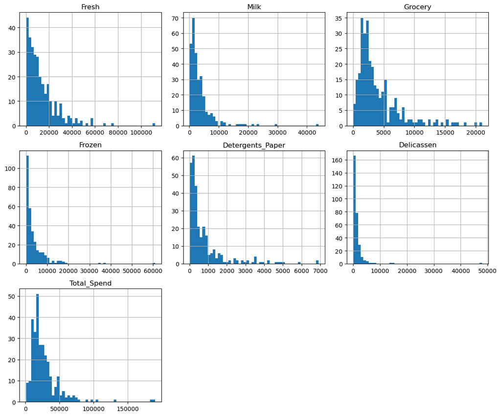

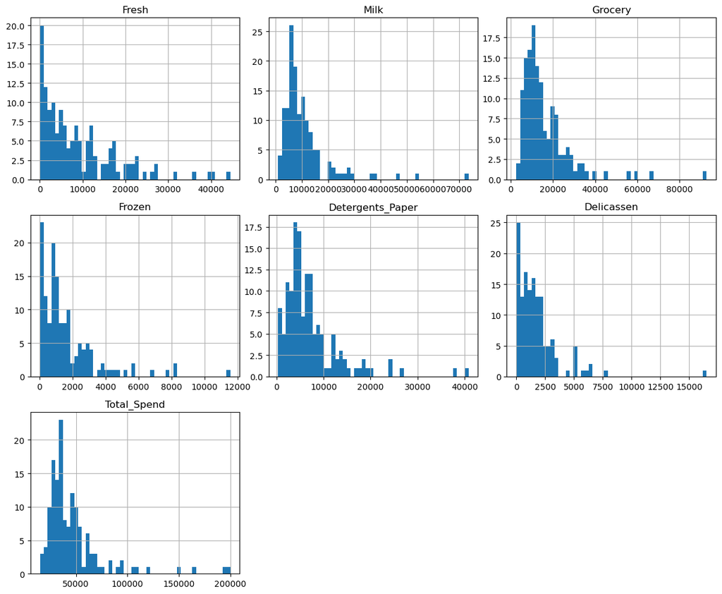

```python
# Plot df_horeca annual spending across product categories
df_horeca.drop(columns=['Channel', 'Region']).hist(figsize=(12, 10), bins=50)

plt.tight_layout()
plt.show()

# Plot df_retail pending across product categories
df_retail.drop(columns=['Channel', 'Region']).hist(figsize=(12, 10), bins=50)

plt.tight_layout()
plt.show()
```

```python
df_horeca['Total_Spend'].describe()
```

```
count       298.000000
mean      26844.191275
std       22164.839073
min         904.000000
25%       13859.250000
50%       21254.500000
75%       32113.750000
max      190169.000000
Name: Total_Spend, dtype: float64
```

```python
df_retail['Total_Spend'].describe()
```

```
count       142.000000
mean      46619.232394
std       29346.866491
min       14993.000000
25%       30147.250000
50%       37139.000000
75%       51650.500000
max      199891.000000
Name: Total_Spend, dtype: float64
```

#### Upon examining the histograms from both the horeca and retail channels, we made several observations:

- Despite Horeca customers making up nearly 68% of the total, their average annual spending across all categories is only 26,844 while Retail customers account for 46619
- Retail customers spend more on Milk, Groceries, and Detergents_paper than Horeca customers.
- Both channels see similar overall spending patterns for the rest of the categories, despite Horeca customers slightly spend more on food-related categories such as: Fresh produce and Frozen products.

## Task 3: Data Modelling

In this Task, We're going to use K-Nearest Neighbours (KNN) and DecisionTree classification model to make a prediction for 'Channel' feature.

### 3.1 Splitting the dataset

```python
# Split data into features and target
X = df.drop('Channel', axis=1)
y = df['Channel']
```

```python
# Split data into training and testing sets with different ratios:
# Suite1: 50% for training and 50% for testing:
from sklearn.model_selection import train_test_split
X1_train, X1_test, y1_train, y1_test = train_test_split(X, y, test_size = 0.5, random_state=1)

# Suite2: 60% for training and 40% for testing:
X2_train, X2_test, y2_train, y2_test = train_test_split(X, y, test_size = 0.4, random_state=2)

# Suite3: 80% for training and 20% for testing:
X3_train, X3_test, y3_train, y3_test = train_test_split(X, y, test_size = 0.2, random_state=3)
```

### 3.2 and 3.3 Applying Classification models on these 3 suites and Comparing the two chosen models

### Applying on Suite1

### KNN model

```python
# Firstly, we're use cross-validation method to find the right K for Suite1
from sklearn.model_selection import cross_val_score
from sklearn.neighbors import KNeighborsClassifier

neighbors = list(range(1, 50, 2))
cv_scores = []

# Perform 10-fold cross-validation
for k in neighbors:
    knn = KNeighborsClassifier(n_neighbors=k)
    scores = cross_val_score(knn, X1_train, y1_train, cv=10, scoring='accuracy')
    cv_scores.append(scores.mean())

# Find the optimal value of K that maximizes accuracy
optimal_k = neighbors[cv_scores.index(max(cv_scores))]

print("Optimal value of K:", optimal_k)
```

```
Optimal value of K: 15
```

```python
knn = KNeighborsClassifier(n_neighbors=15)
knn_trained = knn.fit(X1_train, y1_train)
y1_pred = knn_trained.predict(X1_test)
```

```python
# Evaluating the performances of the model on Suite1 in terms of Confusion matrix, Classification accuracy,
# Precision, Recall and F1 score:
from sklearn.metrics import confusion_matrix, accuracy_score, precision_score, recall_score, f1_score

# Calculate and print metrics
con_knn1 = confusion_matrix(y1_test, y1_pred)
acc_knn1 = accuracy_score(y1_test, y1_pred)
prec_knn1 = precision_score(y1_test, y1_pred, average='weighted')
recall_knn1 = recall_score(y1_test, y1_pred, average='weighted')
f1_knn1 = f1_score(y1_test, y1_pred, average='weighted')
metrics_knn1 = [acc_knn1, prec_knn1, recall_knn1, f1_knn1]
print("Confusion Matrix KNN 1:\n", con_knn1)
print(metrics_knn1)
```

```
Confusion Matrix KNN 1:
 [[136   8]
 [ 15  61]]
[0.8954545454545455, 0.8949262274341456, 0.8954545454545455, 0.8941714042824506]
```

### DecisionTree model

```python
from sklearn.tree import DecisionTreeClassifier
dt = DecisionTreeClassifier()
dt_trained = dt.fit(X1_train, y1_train)
y_pred1 = dt_trained.predict(X1_test)
```

```python
# Calculate and print metrics
con_dt1 = confusion_matrix(y1_test, y_pred1)
acc_dt1 = accuracy_score(y1_test, y_pred1)
prec_dt1 = precision_score(y1_test, y_pred1, average='weighted')
recall_dt1 = recall_score(y1_test, y_pred1, average='weighted')
f1_dt1 = f1_score(y1_test, y_pred1, average='weighted')
metrics_dt1 = [acc_dt1, prec_dt1, recall_dt1, f1_dt1]
print("Confusion Matrix DT 1:\n", con_dt1)
print(metrics_dt1)
```

```
Confusion Matrix DT 1:
 [[133  11]
 [ 15  61]]
[0.8818181818181818, 0.8808831558831559, 0.8818181818181818, 0.881030594729225]
```

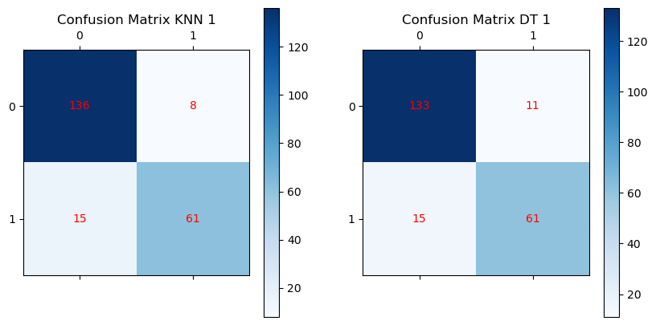

```python
# Comparing the two chosen models
# Create a figure with two subplots
fig, axs = plt.subplots(1, 2, figsize=(10, 5))

# Plot the first confusion matrix
cax1 = axs[0].matshow(con_knn1, cmap=plt.cm.Blues)
fig.colorbar(cax1, ax=axs[0])
axs[0].set_title('Confusion Matrix KNN 1')

# Plot the second confusion matrix
cax2 = axs[1].matshow(con_dt1, cmap=plt.cm.Blues)
fig.colorbar(cax2, ax=axs[1])
axs[1].set_title('Confusion Matrix DT 1')

# Loop over data dimensions and create text annotations
for i in range(2):
    for j in range(2):
        axs[0].text(j, i, con_knn1[i, j], ha='center', va='center', color='red')
        axs[1].text(j, i, con_dt1[i, j], ha='center', va='center', color='red')

plt.show()
```

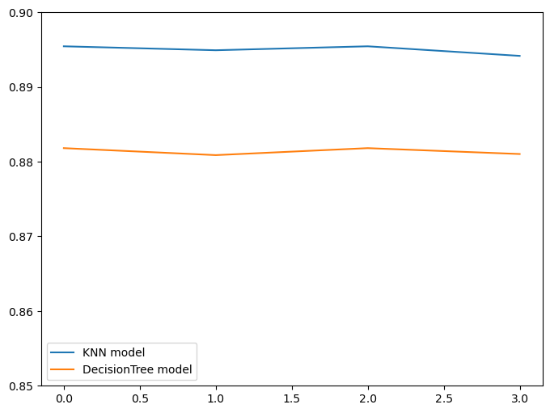

```python
plt.figure(figsize=(8, 6))
plt.plot(metrics_knn1, label='KNN model')
plt.plot(metrics_dt1, label='DecisionTree model')
plt.ylim(0.85, 0.9)
plt.legend()
plt.show()
```

### Applying on Suite2

### KNN model

```python
# Use the same method to find the right K for Suite2:
neighbors = list(range(1, 50, 2))
cv_scores = []
for k in neighbors:
    knn = KNeighborsClassifier(n_neighbors=k)
    scores = cross_val_score(knn, X2_train, y2_train, cv=10, scoring='accuracy')
    cv_scores.append(scores.mean())
optimal_k = neighbors[cv_scores.index(max(cv_scores))]

print("Optimal value of K for Suite2:", optimal_k)
```

```
Optimal value of K for Suite2: 17
```

```python
knn = KNeighborsClassifier(n_neighbors=17)
knn_trained = knn.fit(X2_train, y2_train)
y2_pred = knn_trained.predict(X2_test)
```

```python
# Calculate and print metrics
con_knn2 = confusion_matrix(y2_test, y2_pred)
acc_knn2 = accuracy_score(y2_test, y2_pred)
prec_knn2 = precision_score(y2_test, y2_pred, average='weighted')
recall_knn2 = recall_score(y2_test, y2_pred, average='weighted')
f1_knn2 = f1_score(y2_test, y2_pred, average='weighted')
metrics_knn2 = [acc_knn2, prec_knn2, recall_knn2, f1_knn2]
print("Confusion Matrix KNN 1:\n", con_knn2)
print(metrics_knn2)
```

```
Confusion Matrix KNN 1:
 [[108   7]
 [ 13  48]]
[0.8863636363636364, 0.8856874530428249, 0.8863636363636364, 0.8848692949365072]
```

### DecisionTree model

```python
dt = DecisionTreeClassifier()
dt_trained = dt.fit(X2_train, y2_train)
y_pred2 = dt_trained.predict(X2_test)
```

```python
# Calculate and print metrics
con_dt2 = confusion_matrix(y2_test, y_pred2)
acc_dt2 = accuracy_score(y2_test, y_pred2)
prec_dt2 = precision_score(y2_test, y_pred2, average='weighted')
recall_dt2 = recall_score(y2_test, y_pred2, average='weighted')
f1_dt2 = f1_score(y2_test, y_pred2, average='weighted')
metrics_dt2 = [acc_dt2, prec_dt2, recall_dt2, f1_dt2]
print("Confusion Matrix DT 1:\n", con_dt2)
print(metrics_dt2)
```

```
Confusion Matrix DT 1:
 [[105  10]
 [  9  52]]
[0.8920454545454546, 0.8925133122395432, 0.8920454545454546, 0.8922485855465939]
```

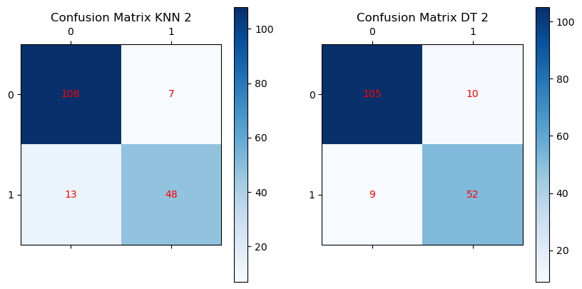

```python
# Comparing the confusion_matrix
fig, axs = plt.subplots(1, 2, figsize=(10, 5))

# Plot the first confusion matrix
cax1 = axs[0].matshow(con_knn2, cmap=plt.cm.Blues)
fig.colorbar(cax1, ax=axs[0])
axs[0].set_title('Confusion Matrix KNN 2')

# Plot the second confusion matrix
cax2 = axs[1].matshow(con_dt2, cmap=plt.cm.Blues)
fig.colorbar(cax2, ax=axs[1])
axs[1].set_title('Confusion Matrix DT 2')

# Loop over data dimensions and create text annotations
for i in range(2):
    for j in range(2):
        axs[0].text(j, i, con_knn2[i, j], ha='center', va='center', color='red')
        axs[1].text(j, i, con_dt2[i, j], ha='center', va='center', color='red')

plt.show()
```

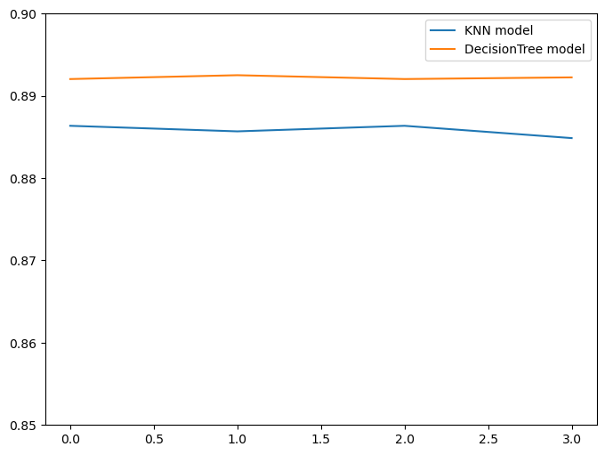

```python
# Comparing the other values
plt.figure(figsize=(8, 6))
plt.plot(metrics_knn2, label='KNN model')
plt.plot(metrics_dt2, label='DecisionTree model')
plt.ylim(0.85, 0.9)
plt.legend()
plt.show()
```

### Applying on Suite3

### KNN model

```python
neighbors = list(range(1, 50, 2))
cv_scores = []
for k in neighbors:
    knn = KNeighborsClassifier(n_neighbors=k)
    scores = cross_val_score(knn, X3_train, y3_train, cv=10, scoring='accuracy')
    cv_scores.append(scores.mean())
optimal_k = neighbors[cv_scores.index(max(cv_scores))]

print("Optimal value of K for Suite3:", optimal_k)
```

```
Optimal value of K for Suite3: 3
```

```python
knn = KNeighborsClassifier(n_neighbors=3)
knn_trained = knn.fit(X3_train, y3_train)
y3_pred = knn_trained.predict(X3_test)
```

```python
# Calculate and print metrics
con_knn3 = confusion_matrix(y3_test, y3_pred)
acc_knn3 = accuracy_score(y3_test, y3_pred)
prec_knn3 = precision_score(y3_test, y3_pred, average='weighted')
recall_knn3 = recall_score(y3_test, y3_pred, average='weighted')
f1_knn3 = f1_score(y3_test, y3_pred, average='weighted')
metrics_knn3 = [acc_knn3, prec_knn3, recall_knn3, f1_knn3]
print("Confusion Matrix KNN 3:\n", con_knn3)
print(metrics_knn3)
```

```
Confusion Matrix KNN 3:
 [[52  2]
 [ 4 30]]
[0.9318181818181818, 0.9320211038961038, 0.9318181818181818, 0.931404958677686]
```

### DecisionTree model

```python
dt = DecisionTreeClassifier()
dt_trained = dt.fit(X3_train, y3_train)
y_pred3 = dt_trained.predict(X3_test)
```

```python
# Calculate and print metrics
con_dt3 = confusion_matrix(y3_test, y_pred3)
acc_dt3 = accuracy_score(y3_test, y_pred3)
prec_dt3 = precision_score(y3_test, y_pred3, average='weighted')
recall_dt3 = recall_score(y3_test, y_pred3, average='weighted')
f1_dt3 = f1_score(y3_test, y_pred3, average='weighted')
metrics_dt3 = [acc_dt3, prec_dt3, recall_dt3, f1_dt3]
print("Confusion Matrix DT 3:\n", con_dt3)
print(metrics_dt3)
```

```
Confusion Matrix DT 3:
 [[49  5]
 [ 9 25]]
[0.8409090909090909, 0.8403866248693835, 0.8409090909090909, 0.8387784090909091]
```

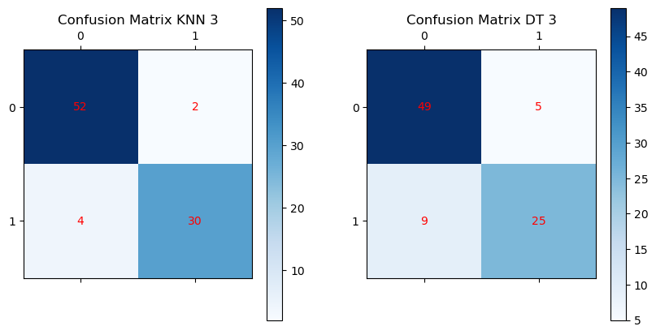

```python
# Comparing the confusion_matrix
fig, axs = plt.subplots(1, 2, figsize=(10, 5))

# Plot the first confusion matrix
cax1 = axs[0].matshow(con_knn3, cmap=plt.cm.Blues)
fig.colorbar(cax1, ax=axs[0])
axs[0].set_title('Confusion Matrix KNN 3')

# Plot the second confusion matrix
cax2 = axs[1].matshow(con_dt3, cmap=plt.cm.Blues)
fig.colorbar(cax2, ax=axs[1])
axs[1].set_title('Confusion Matrix DT 3')

# Loop over data dimensions and create text annotations
for i in range(2):
    for j in range(2):
        axs[0].text(j, i, con_knn3[i, j], ha='center', va='center', color='red')
        axs[1].text(j, i, con_dt3[i, j], ha='center', va='center', color='red')

plt.show()
```

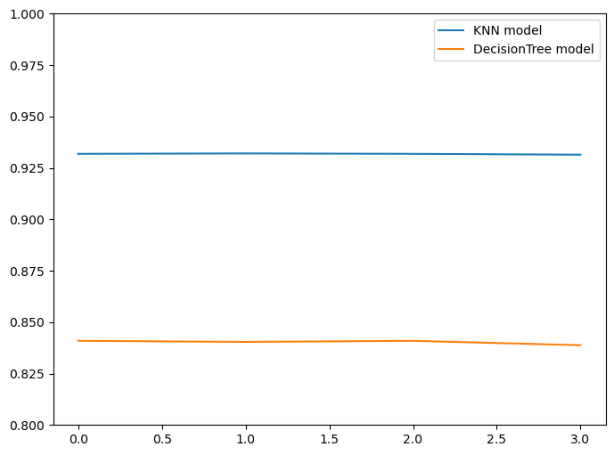

```python
# Comparing the other values
plt.figure(figsize=(8, 6))
plt.plot(metrics_knn3, label='KNN model')
plt.plot(metrics_dt3, label='DecisionTree model')
plt.ylim(0.8, 1)
plt.legend()
plt.show()
```

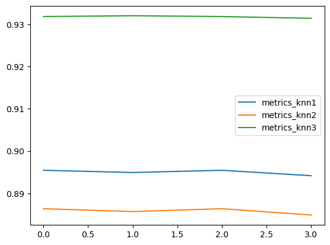

```python
# Compare the scores between 3 Suites when apply KNN model
plt.plot(metrics_knn1, label='metrics_knn1')
plt.plot(metrics_knn2, label='metrics_knn2')
plt.plot(metrics_knn3, label='metrics_knn3')
plt.legend()
plt.show()
```

[figure not shown]

```python
# Compare the scores between 3 Suites when apply Decision Tree model
plt.plot(metrics_dt1, label='metrics_dt1')
plt.plot(metrics_dt2, label='metrics_dt2')
plt.plot(metrics_dt3, label='metrics_dt3')
plt.legend()
plt.show()
```